# Import libraries

```python
# basics :
import pandas as pd
import numpy as np
import datetime

# plot
import matplotlib.pyplot as plt
import seaborn as sns
%matplotlib inline

# impute and scale data
from sklearn.preprocessing import Imputer, StandardScaler, OneHotEncoder, FunctionTransformer
from sklearn.decomposition import PCA
# models
from sklearn.tree import DecisionTreeClassifier
from sklearn.linear_model import LogisticRegression
from sklearn.neighbors import KNeighborsClassifier
from sklearn.ensemble import GradientBoostingClassifier, RandomForestClassifier
# selection, pipeline
from sklearn.model_selection import GridSearchCV, RandomizedSearchCV, train_test_split, cross_val_score
from sklearn.pipeline import Pipeline, FeatureUnion
# metrics
from sklearn import metrics
from sklearn.metrics import classification_report, confusion_matrix, accuracy_score, roc_auc_score
# save models
from sklearn.externals import joblib
```

# Load data

```python
# read data
variabletypes = pd.read_excel('caseintro/variabletypes.xlsx')
```

```python
raw_data = pd.read_csv('caseintro/Assignment_Data.csv', sep=";")
```

```python
# df for modelling and df_test for prediction submission
df = raw_data[raw_data.Target.isnull() == False]
df_test = raw_data[raw_data.Target.isnull() == True]
```

```python
n = df.shape[0]
```

# Inspect data

```python
df.shape, df_test.shape
```

```
((2057, 55), (515, 55))
```

```python
variabletypes
```

|  | Test_Name | Type |
| --- | --- | --- |
| 0 | country_id | ID |
| 1 | application_id | ID |
| 2 | product_id | ID |
| 3 | v1 | Numeric |
| 4 | v2 | Numeric |
| 5 | v3 | Numeric |
| 6 | v4 | Numeric |
| 7 | v5 | Categorical |
| 8 | v6 | Categorical |
| 9 | v7 | Numeric |
| 10 | due_date | Date |
| 11 | first_status_day_date | Date |
| 12 | first_status_time_of_day | Date |
| 13 | paid_date | Date |
| 14 | v8 | Numeric |
| 15 | customer_id | ID |
| 16 | arrived_date | Date |
| 17 | v9 | Numeric |
| 18 | v10 | Numeric |
| 19 | v11 | Numeric |
| 20 | v12 | Categorical |
| 21 | v13 | Ordinal |
| 22 | v14 | Ordinal |
| 23 | v15 | Numeric |
| 24 | v16 | Numeric |
| 25 | v17 | Numeric |
| 26 | v18 | Numeric |
| 27 | v19 | Numeric |
| 28 | v20 | Numeric |
| 29 | v21 | Numeric |
| 30 | v22 | Numeric |
| 31 | v23 | Numeric |
| 32 | v24 | Numeric |
| 33 | v25 | Numeric |
| 34 | v26 | Numeric |
| 35 | v27 | Numeric |
| 36 | v28 | Numeric |
| 37 | v29 | Numeric |
| 38 | v30 | Numeric |
| 39 | v31 | Numeric |
| 40 | v32 | Numeric |
| 41 | v33 | Numeric |
| 42 | v34 | Numeric |
| 43 | v35 | Numeric |
| 44 | v36 | Numeric |
| 45 | v37 | Numeric |
| 46 | v38 | Numeric |
| 47 | v39 | Numeric |
| 48 | v40 | Numeric |
| 49 | v41 | Numeric |
| 50 | v42 | Date |
| 51 | v43 | Date |
| 52 | v44 | Date |
| 53 | v45 | Categorical |
| 54 | Target | Binary |

```python
variabletypes.groupby('Type').size()
```

```
Type
Binary          1
Categorical     4
Date            8
ID              4
Numeric        36
Ordinal         2
dtype: int64
```

Ordinal is like categoricals but with order.

# y

Circa 70% so we guess this variable indicates whether they pay back the loan.

# Clean data

```python
# rename for quicker typing
df.columns = df.columns.str.replace('Variable_', 'v')
variabletypes.columns = variabletypes.columns.str.replace('Variable_', 'v')
df.rename(columns = {'Target':'y'}, inplace = True)
```

```python
df.y.mean()
```

```
0.6922702965483715
```

```python
df.head().T
```

|  | 0 | 1 | 2 | 3 | 4 |
| --- | --- | --- | --- | --- | --- |
| country_id | 21 | 21 | 21 | 21 | 21 |
| application_id | 24176 | 24185 | 24215 | 24220 | 24255 |
| product_id | 21210001 | 21210001 | 21210001 | 21210001 | 21210001 |
| v1 | 35 | 30 | 30 | 30 | 30 |
| v2 | 1 | 1 | 1 | 1 | 2 |
| v3 | 1 | 1 | 1 | 1 | 1 |
| v4 | 1 | 1 | 1 | 1 | 1 |
| v5 | N | N | N | N | N |
| v6 | 72 | 25 | 65 | 65 | 4 |
| v7 | 27 | 26 | 21 | 48 | 28 |
| due_date | 07/07/2015 | 02/07/2015 | 02/07/2015 | 17/07/2015 | 02/07/2015 |
| first_status_day_date | 01/06/2015 | 01/06/2015 | 01/06/2015 | 01/06/2015 | 01/06/2015 |
| first_status_time_of_day | 00:43:22 | 07:56:36 | 11:02:04 | 11:22:37 | 15:27:18 |
| paid_date | 02/06/2015 | 02/06/2015 | 02/06/2015 | 17/06/2015 | 02/06/2015 |
| v8 | 100 | 199 | 100 | 199 | 199 |
| customer_id | 2970192 | 2970195 | 2970204 | 2970206 | 2430110 |
| arrived_date | 01/06/2015 00:43 | 01/06/2015 07:56 | 01/06/2015 11:02 | 01/06/2015 11:22 | 01/06/2015 15:27 |
| v9 | 190 | 199 | 100 | 199 | 600 |
| v10 | 100 | 199 | 100 | 199 | 199 |
| v11 | 100 | 199 | 100 | 199 | 199 |
| v12 | 15 | 15 | 15 | 15 | 15 |
| v13 | M | M | G | D | NaN |
| v14 | RATINGSTUFE M | RATINGSTUFE M | RATINGSTUFE G | RATINGSTUFE D | NaN |
| v15 | 0 | 4 | 1 | 0 | NaN |
| v16 | 0 | 1 | 2 | 0 | NaN |
| v17 | 0 | 0 | 0 | 0 | NaN |
| v18 | 0 | 0 | 0 | 0 | NaN |
| v19 | 1 | 0 | 0 | 0 | NaN |
| v20 | NaN | 25000 | 499 | NaN | NaN |
| v21 | NaN | NaN | NaN | NaN | NaN |
| v22 | NaN | 100 | 200 | NaN | NaN |
| v23 | 1 | 0 | 0 | 0 | NaN |
| v24 | 0 | 0 | 0 | 0 | NaN |
| v25 | 0 | 0 | 0 | 0 | NaN |
| v26 | 0 | 0 | 0 | 0 | NaN |
| v27 | 1 | 4 | 0 | 0 | NaN |
| v28 | 0 | 0 | 0 | 0 | NaN |
| v29 | 0 | 0 | 0 | 0 | NaN |
| v30 | 0 | 0 | 0 | 0 | NaN |
| v31 | 0 | 0 | 0 | 0 | NaN |
| v32 | 0 | 0 | 0 | 0 | NaN |
| v33 | 0 | 0 | 0 | 0 | NaN |
| v34 | 0 | 0 | 0 | 0 | NaN |
| v35 | 0 | 0 | 0 | 0 | NaN |
| v36 | 0 | 0 | 0 | 0 | NaN |
| v37 | NaN | 40147 | 499 | NaN | NaN |
| v38 | NaN | NaN | NaN | NaN | NaN |
| v39 | NaN | 100 | 300 | NaN | NaN |
| v40 | 0 | 0 | 0 | 0 | NaN |
| v41 | 0 | 0 | 0 | 0 | NaN |
| v42 | NaN | NaN | NaN | NaN | NaN |
| v43 | NaN | NaN | NaN | NaN | NaN |
| v44 | 14/06/2013 | NaN | NaN | NaN | NaN |
| v45 | F | M | F | F | F |
| y | 1 | 1 | 0 | 1 | 1 |

Based on the output above:

- Remove variables with only 1 unique value are removed, as they won't be predictive. (Later, in the feature selection, we might remove cols with low variance.)
- Recode v45 into Male
- v5 is a boolean qq recode
- arrived_date contains date & time, split it up? qq
- v14 must be recoded?

```python
# Remove zero variance variabls
cols_novariance = df.columns[df.apply(lambda x: x.nunique() == 1).values]
df.drop(cols_novariance, inplace = True, axis = 1)
```

```python
# Rename and recode Variable 45 to Male = True/False, elr så är det gjort med ett paket.
```

```python
# Variable_14 must recode something? qq
```

```python
df.v45.unique() # see that this must be recoded
df.loc[df.v45 == 'M', 'v45'] = 1
df.loc[df.v45 == 'F', 'v45'] = 0
df.loc[df.v45 == '?', 'v45'] = np.nan
```

```python
# cols with NA count > 40%
cols_manyna = df.isnull().mean().sort_values().tail(9).index
df.isnull().mean().sort_values().tail(9)
```

```
v20    0.415654
v37    0.415654
v22    0.688381
v39    0.688381
v21    0.770540
v38    0.770540
v44    0.916869
v43    0.942149
v42    0.954302
dtype: float64
```

```python
df.drop(cols_manyna, inplace = True, axis = 1) # qq test performance with/without this
```

There is a clear "elbow" at 9 values since the 10th value has only 7% NA whereas the 9th value has 42 NA.

# Correct dtype

```python
# save cols with different dtypes (must intersect with df.columns because some are dropped)
cols_cat = list(set(variabletypes[variabletypes.Type == 'Categorical'].Test_Name) & set(df.columns))
cols_cato = list(set(variabletypes[variabletypes.Type == 'Ordinal'].Test_Name) & set(df.columns))
cols_num = list(set(variabletypes[variabletypes.Type == 'Numeric'].Test_Name) & set(df.columns))
cols_date = list(set(variabletypes[variabletypes.Type == 'Date'].Test_Name) & set(df.columns))
cols_id = list(set(variabletypes[variabletypes.Type == 'ID'].Test_Name) & set(df.columns))
```

# EDA

## Date columns

```python
# convert to correct time (see other project and sNotes for attempt at generalizing the approach . qqe2)
df[cols_date].head()
```

|  | arrived_date | due_date | first_status_day_date | paid_date | first_status_time_of_day |
| --- | --- | --- | --- | --- | --- |
| 0 | 01/06/2015 00:43 | 07/07/2015 | 01/06/2015 | 02/06/2015 | 00:43:22 |
| 1 | 01/06/2015 07:56 | 02/07/2015 | 01/06/2015 | 02/06/2015 | 07:56:36 |
| 2 | 01/06/2015 11:02 | 02/07/2015 | 01/06/2015 | 02/06/2015 | 11:02:04 |
| 3 | 01/06/2015 11:22 | 17/07/2015 | 01/06/2015 | 17/06/2015 | 11:22:37 |
| 4 | 01/06/2015 15:27 | 02/07/2015 | 01/06/2015 | 02/06/2015 | 15:27:18 |

```python
# split arrived_date into two cols: one for date one for time
df['arrived_time_of_day'] = pd.DatetimeIndex(df['arrived_date']).time
df['arrived_date'] = pd.DatetimeIndex(df['arrived_date']).date
df['arrived_date'] = pd.to_datetime(df['arrived_date'])
```

```python
cols_date2 = ['paid_date', 'due_date', 'first_status_day_date']
df[cols_date2] = df[cols_date2].apply(lambda x: pd.to_datetime(x))
del cols_date2
```

```python
cols_date = cols_date + ['arrived_time_of_day']
```

```python
df[cols_date].head()
```

|  | arrived_date | due_date | first_status_day_date | paid_date | first_status_time_of_day | arrived_time_of_day |
| --- | --- | --- | --- | --- | --- | --- |
| 0 | 2015-01-06 | 2015-07-07 | 2015-01-06 | 2015-02-06 | 00:43:22 | 00:43:00 |
| 1 | 2015-01-06 | 2015-02-07 | 2015-01-06 | 2015-02-06 | 07:56:36 | 07:56:00 |
| 2 | 2015-01-06 | 2015-02-07 | 2015-01-06 | 2015-02-06 | 11:02:04 | 11:02:00 |
| 3 | 2015-01-06 | 2015-07-17 | 2015-01-06 | 2015-06-17 | 11:22:37 | 11:22:00 |
| 4 | 2015-01-06 | 2015-02-07 | 2015-01-06 | 2015-02-06 | 15:27:18 | 15:27:00 |

qq We must probably create som smart column in order to get something out of these date and time variables. For example a variable measuring if they signed up during the night.

```python
df[cols_date].dtypes
```

```
arrived_date                datetime64[ns]
due_date                    datetime64[ns]
first_status_day_date       datetime64[ns]
paid_date                   datetime64[ns]
first_status_time_of_day            object
arrived_time_of_day                 object
dtype: object
```

qq all are not times or dates, this must be fixed.

```
df[cols_date].apply(lambda x: pd.to_datetime(x))
```

gave an error.

qq below gives errors for some reason.

Tried `df.arrived_date - df.first_status_day_date).dt.days` but all are zero.

```python
def to_time(x):
    df[x] = pd.to_datetime(df[x]).dt.time
```

```python
to_time('first_status_time_of_day')
```

```python
# to_time('arrived_time_of_day')
```

```python
# df.arrived_time_of_day, df.first_status_time_of_day
df.loc[1:10, ['arrived_time_of_day', 'first_status_time_of_day']]
```

|  | arrived_time_of_day | first_status_time_of_day |
| --- | --- | --- |
| 1 | 07:56:00 | 07:56:36 |
| 2 | 11:02:00 | 11:02:04 |
| 3 | 11:22:00 | 11:22:37 |
| 4 | 15:27:00 | 15:27:18 |
| 5 | 16:02:00 | 16:02:03 |
| 6 | 16:46:00 | 16:46:03 |
| 7 | 23:43:00 | 23:43:57 |
| 8 | 10:55:00 | 10:55:47 |
| 9 | 11:47:00 | 11:47:21 |
| 10 | 12:05:00 | 12:05:15 |

```python
# (df.arrived_time_of_day - df.first_status_time_of_day).dt.seconds # qq error, why?
```

```python
df['dt_due_paid'] = (df.due_date - df.paid_date).dt.days
```

```python
df['overdue'] = df.dt_due_paid < 0
```

```python
# qq create days overdue
```

```python
# qq do some custumers show up twice?
```

```python
assert df.customer_id.nunique() == n
```

## Categorical columns

```python
df[cols_cat].apply(lambda x: x.nunique())
```

```
v6     96
v45     2
v12     6
dtype: int64
```

qq v6 has 96 categories. creates a lot of dummies. maybe a bad col to use.

```python
df.v45.unique(), df.v12.unique()
```

```
(array([0, 1, nan], dtype=object),
 array([ 15. ,   0. ,  99. ,  45. ,  22.5,  31.5]))
```

v12 looks strange. Maybe it's strange on purpose so that we apply one hot encoding to categorical variables.

## Ordinal columns (ordered categorical)

```python
df[cols_cato].apply(lambda x: x.nunique())
```

```
v14    12
v13    12
dtype: int64
```

```python
df.v13.unique()
```

```
array(['M', 'G', 'D', nan, 'K', 'I', 'F', 'H', 'L', 'E', 'B', 'C', 'A'], dtype=object)
```

```python
df.v13.isnull().sum()
```

```
54
```

```python
df.v14.unique()
```

```
array(['RATINGSTUFE M', 'RATINGSTUFE G', 'RATINGSTUFE D', nan,
       'RATINGSTUFE K', 'RATINGSTUFE I', 'RATINGSTUFE F', 'RATINGSTUFE H',
       'RATINGSTUFE L', 'RATINGSTUFE E', 'RATINGSTUFE B', 'RATINGSTUFE C',
       'RATINGSTUFE A'], dtype=object)
```

```python
df.v14.isnull().sum()
```

```
54
```

```python
df.loc[1:5, ['v13', 'v14']]
```

|  | v13 | v14 |
| --- | --- | --- |
| 1 | M | RATINGSTUFE M |
| 2 | G | RATINGSTUFE G |
| 3 | D | RATINGSTUFE D |
| 4 | NaN | NaN |
| 5 | K | RATINGSTUFE K |

Coincidence? I think not.

```python
# qq write code that assert v13 and v14 are the same
# assert 0 == (df.v14.replace('RATINGSTUFE ', '') != df.v13).sum()
```

```python
df.drop('v14', inplace = True, axis = 1)
```

qq does sklearn care if I do onehot encoding or code it as 1,2,3,4,... ? I will anyway for now Do it like

```python
df.v13 = df.v13.map({'A':1, 'B':2, 'C':3, 'D':4, 'E':5, 'F':6, 'G':7, 'H':8, 'I':9, 'J':10, 'K':11, 'L':12})
```

qq ad v13 to _col ? and them remove _colo?

## Numerical columns

```python
df[cols_num].describe()
```

|  | v18 | v27 | v8 | v1 | v29 | v19 | v25 | v4 | v7 | v26 | ... | v35 | v23 | v15 | v11 | v41 | v17 | v16 | v2 | v24 | v40 |
| --- | --- | --- | --- | --- | --- | --- | --- | --- | --- | --- | --- | --- | --- | --- | --- | --- | --- | --- | --- | --- | --- |
| count | 1910.000000 | 1910.000000 | 2057.000000 | 2057.000000 | 1910.000000 | 1910.000000 | 1910.000000 | 2057.000000 | 2056.000000 | 1910.000000 | ... | 1910.000000 | 1910.000000 | 1910.000000 | 2057.000000 | 1910.000000 | 1910.000000 | 1910.000000 | 2057.00000 | 1910.00000 | 1910.000000 |
| mean | 0.583770 | 1.911518 | 197.083617 | 33.634905 | 0.068063 | 0.434555 | 0.020942 | 1.000972 | 32.388132 | 0.339791 | ... | 0.087958 | 0.147644 | 2.193194 | 202.875061 | 0.004188 | 0.328796 | 1.206806 | 1.31016 | 0.03822 | 0.194764 |
| std | 0.865525 | 3.400309 | 109.459238 | 8.894507 | 0.387840 | 0.933998 | 0.157179 | 0.031174 | 11.473110 | 0.674491 | ... | 0.422782 | 0.564519 | 2.683371 | 80.494015 | 0.064600 | 0.665515 | 3.015875 | 0.72481 | 0.20752 | 0.458633 |
| min | 0.000000 | 0.000000 | 0.000000 | 7.000000 | 0.000000 | 0.000000 | 0.000000 | 1.000000 | 18.000000 | 0.000000 | ... | 0.000000 | 0.000000 | 0.000000 | 50.000000 | 0.000000 | 0.000000 | 0.000000 | 1.00000 | 0.00000 | 0.000000 |
| 25% | 0.000000 | 0.000000 | 100.000000 | 30.000000 | 0.000000 | 0.000000 | 0.000000 | 1.000000 | 24.000000 | 0.000000 | ... | 0.000000 | 0.000000 | 0.000000 | 190.000000 | 0.000000 | 0.000000 | 0.000000 | 1.00000 | 0.00000 | 0.000000 |
| 50% | 0.000000 | 1.000000 | 199.000000 | 30.000000 | 0.000000 | 0.000000 | 0.000000 | 1.000000 | 29.000000 | 0.000000 | ... | 0.000000 | 0.000000 | 1.000000 | 199.000000 | 0.000000 | 0.000000 | 0.000000 | 1.00000 | 0.00000 | 0.000000 |
| 75% | 1.000000 | 2.000000 | 199.000000 | 30.000000 | 0.000000 | 1.000000 | 0.000000 | 1.000000 | 38.000000 | 1.000000 | ... | 0.000000 | 0.000000 | 4.000000 | 200.000000 | 0.000000 | 0.000000 | 1.000000 | 1.00000 | 0.00000 | 0.000000 |
| max | 7.000000 | 32.000000 | 500.000000 | 60.000000 | 10.000000 | 7.000000 | 3.000000 | 2.000000 | 86.000000 | 5.000000 | ... | 8.000000 | 11.000000 | 20.000000 | 500.000000 | 1.000000 | 5.000000 | 32.000000 | 10.00000 | 2.00000 | 4.000000 |

8 rows × 23 columns

```python
# qq write code to check if any of the cols above are identical, or simple tranformations of each other (will lead to collinearyt for example)
```

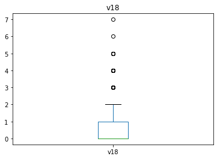

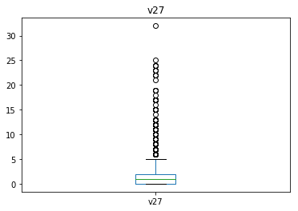

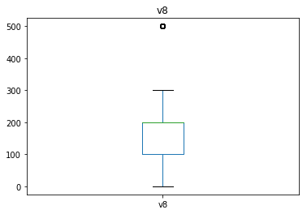

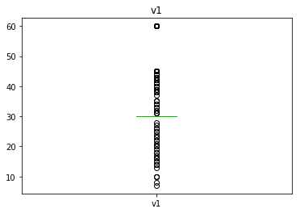

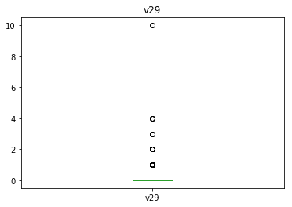

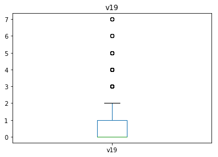

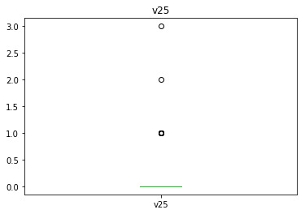

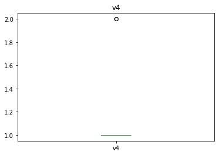

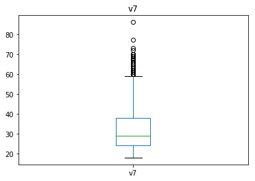

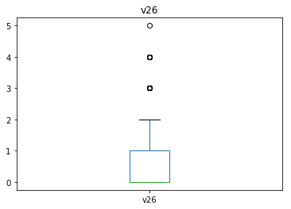

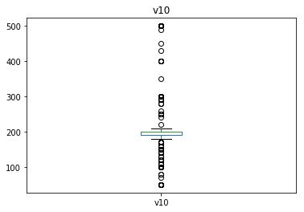

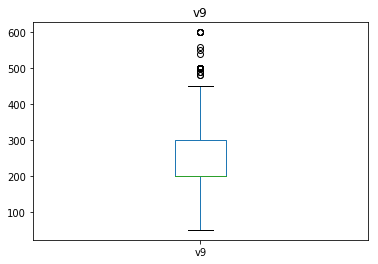

[11 more figures not shown]

```python
for col in cols_num:
    df[col].plot.box()
    plt.title(col)
    plt.show()
```

Boxplots look strange for many columns. qq

```python
df[cols_num].apply(lambda x: x.nunique())
```

```
v18     8
v27    26
v8      5
v1     35
v29     6
v19     8
v25     4
v4      2
v7     57
v26     6
v10    29
v9     39
v36     2
v35     7
v23     8
v15    19
v11    29
v41     2
v17     6
v16    27
v2      9
v24     3
v40     5
dtype: int64
```

Why has a numerical column in a dataset with ca 2000 rows, less than 10 nunique? Maybe these are in reality categorical columns.

Even 30 or 40 nunique can be considered low for 2000 datapoints - that's only

```python
40 / n
```

```
0.019445794846864366
```

## Cols with same nr of NA

```python
# some cols have exactly the same nr of NA. are those columns similar?
mask = (df.isnull().sum() == 147).values
cols_na147 = df.columns[mask]
```

```python
df.loc[df.v15.isnull() == True].head().T
```

|  | 4 | 19 | 24 | 31 | 58 |
| --- | --- | --- | --- | --- | --- |
| application_id | 24255 | 24516 | 24603 | 24761 | 25363 |
| v1 | 30 | 45 | 26 | 30 | 45 |
| v2 | 2 | 1 | 1 | 1 | 1 |
| v4 | 1 | 1 | 1 | 1 | 1 |
| v6 | 4 | 39 | 47 | 54 | 46 |
| v7 | 28 | 24 | 19 | 20 | 29 |
| due_date | 2015-02-07 00:00:00 | 2015-07-20 00:00:00 | 2015-08-07 00:00:00 | 2015-08-07 00:00:00 | 2015-01-08 00:00:00 |
| first_status_day_date | 2015-01-06 00:00:00 | 2015-03-06 00:00:00 | 2015-04-06 00:00:00 | 2015-05-06 00:00:00 | 2015-11-06 00:00:00 |
| first_status_time_of_day | 15:27:18 | 13:23:43 | 12:51:14 | 16:01:13 | 11:36:45 |
| paid_date | 2015-02-06 00:00:00 | 2015-05-06 00:00:00 | 2015-12-06 00:00:00 | 2015-08-06 00:00:00 | 2015-06-17 00:00:00 |
| v8 | 199 | 199 | 199 | 199 | 199 |
| customer_id | 2430110 | 2976020 | 2978110 | 2980533 | 2995142 |
| arrived_date | 2015-01-06 00:00:00 | 2015-03-06 00:00:00 | 2015-04-06 00:00:00 | 2015-05-06 00:00:00 | 2015-11-06 00:00:00 |
| v9 | 600 | 100 | 199 | 199 | 300 |
| v10 | 199 | 100 | 199 | 199 | 200 |
| v11 | 199 | 100 | 199 | 199 | 200 |
| v12 | 15 | 0 | 15 | 15 | 15 |
| v13 | NaN | 8 | 7 | 7 | NaN |
| v15 | NaN | NaN | NaN | NaN | NaN |
| v16 | NaN | NaN | NaN | NaN | NaN |
| v17 | NaN | NaN | NaN | NaN | NaN |
| v18 | NaN | NaN | NaN | NaN | NaN |
| v19 | NaN | NaN | NaN | NaN | NaN |
| v23 | NaN | NaN | NaN | NaN | NaN |
| v24 | NaN | NaN | NaN | NaN | NaN |
| v25 | NaN | NaN | NaN | NaN | NaN |
| v26 | NaN | NaN | NaN | NaN | NaN |
| v27 | NaN | NaN | NaN | NaN | NaN |
| v29 | NaN | NaN | NaN | NaN | NaN |
| v35 | NaN | NaN | NaN | NaN | NaN |
| v36 | NaN | NaN | NaN | NaN | NaN |
| v40 | NaN | NaN | NaN | NaN | NaN |
| v41 | NaN | NaN | NaN | NaN | NaN |
| v45 | 0 | 1 | 1 | 1 | 1 |
| y | 1 | 0 | 0 | 1 | 0 |
| arrived_time_of_day | 15:27:00 | 13:23:00 | 12:51:00 | 16:01:00 | 11:36:00 |
| dt_due_paid | 1 | 75 | -121 | 1 | -160 |
| overdue | False | False | True | False | True |

# Quick pipeline test

## 1)

```python
#X = df[['v1', 'v2', 'v4']]
X = df[cols_num]
y = df.y

X.shape, y.shape
```

```
((2057, 23), (2057,))
```

```python
X.describe()
```

|  | v18 | v27 | v8 | v1 | v29 | v19 | v25 | v4 | v7 | v26 | ... | v35 | v23 | v15 | v11 | v41 | v17 | v16 | v2 | v24 | v40 |
| --- | --- | --- | --- | --- | --- | --- | --- | --- | --- | --- | --- | --- | --- | --- | --- | --- | --- | --- | --- | --- | --- |
| count | 1910.000000 | 1910.000000 | 2057.000000 | 2057.000000 | 1910.000000 | 1910.000000 | 1910.000000 | 2057.000000 | 2056.000000 | 1910.000000 | ... | 1910.000000 | 1910.000000 | 1910.000000 | 2057.000000 | 1910.000000 | 1910.000000 | 1910.000000 | 2057.00000 | 1910.00000 | 1910.000000 |
| mean | 0.583770 | 1.911518 | 197.083617 | 33.634905 | 0.068063 | 0.434555 | 0.020942 | 1.000972 | 32.388132 | 0.339791 | ... | 0.087958 | 0.147644 | 2.193194 | 202.875061 | 0.004188 | 0.328796 | 1.206806 | 1.31016 | 0.03822 | 0.194764 |
| std | 0.865525 | 3.400309 | 109.459238 | 8.894507 | 0.387840 | 0.933998 | 0.157179 | 0.031174 | 11.473110 | 0.674491 | ... | 0.422782 | 0.564519 | 2.683371 | 80.494015 | 0.064600 | 0.665515 | 3.015875 | 0.72481 | 0.20752 | 0.458633 |
| min | 0.000000 | 0.000000 | 0.000000 | 7.000000 | 0.000000 | 0.000000 | 0.000000 | 1.000000 | 18.000000 | 0.000000 | ... | 0.000000 | 0.000000 | 0.000000 | 50.000000 | 0.000000 | 0.000000 | 0.000000 | 1.00000 | 0.00000 | 0.000000 |
| 25% | 0.000000 | 0.000000 | 100.000000 | 30.000000 | 0.000000 | 0.000000 | 0.000000 | 1.000000 | 24.000000 | 0.000000 | ... | 0.000000 | 0.000000 | 0.000000 | 190.000000 | 0.000000 | 0.000000 | 0.000000 | 1.00000 | 0.00000 | 0.000000 |
| 50% | 0.000000 | 1.000000 | 199.000000 | 30.000000 | 0.000000 | 0.000000 | 0.000000 | 1.000000 | 29.000000 | 0.000000 | ... | 0.000000 | 0.000000 | 1.000000 | 199.000000 | 0.000000 | 0.000000 | 0.000000 | 1.00000 | 0.00000 | 0.000000 |
| 75% | 1.000000 | 2.000000 | 199.000000 | 30.000000 | 0.000000 | 1.000000 | 0.000000 | 1.000000 | 38.000000 | 1.000000 | ... | 0.000000 | 0.000000 | 4.000000 | 200.000000 | 0.000000 | 0.000000 | 1.000000 | 1.00000 | 0.00000 | 0.000000 |
| max | 7.000000 | 32.000000 | 500.000000 | 60.000000 | 10.000000 | 7.000000 | 3.000000 | 2.000000 | 86.000000 | 5.000000 | ... | 8.000000 | 11.000000 | 20.000000 | 500.000000 | 1.000000 | 5.000000 | 32.000000 | 10.00000 | 2.00000 | 4.000000 |

8 rows × 23 columns

```python
X_train, X_test, y_train, y_test = train_test_split(X, y, test_size = 0.30, random_state=9)
```

```python
steps = [
    # preprocess:
    ('imp', Imputer(strategy='mean')),
    ('scale', StandardScaler()), # zero mean and unit variance

    #('pca', PCA(2)),

    # classifier:
    # ('clf', LogisticRegression())
    ('clf', GradientBoostingClassifier())
]
pipe = Pipeline(steps=steps)
```

[output not shown]

```python
pipe.fit(X_train, y_train)
y_pred_proba = pipe.predict_proba(X_test)[:, 1]
roc_auc_score(y_test, y_pred_proba)
```

```
0.62010536898232393
```

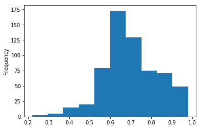

```python
pd.Series(y_pred_proba).plot.hist()
```

## 2)

```python
cols_cat
```

```
['v6', 'v45', 'v12']
```

```python
df[cols_cat].isnull().sum()
```

```
v6     35
v45     7
v12     0
dtype: int64
```

```python
X = df[cols_cat]
```

```python
X.head()
```

|  | v6 | v45 | v12 |
| --- | --- | --- | --- |
| 0 | 72.0 | 0 | 15.0 |
| 1 | 25.0 | 1 | 15.0 |
| 2 | 65.0 | 0 | 15.0 |
| 3 | 65.0 | 0 | 15.0 |
| 4 | 4.0 | 0 | 15.0 |

```python
X_train, X_test, y_train, y_test = train_test_split(X, y, test_size = 0.30, random_state=9)
```

```python
# can be used as a boolean for OneHotEncoder
cols_cat_bool = X.columns.isin(cols_cat)
```

```python
steps2 = [
    # preprocess:
    ('imp', Imputer(strategy='most_frequent')),
    ('onehot', OneHotEncoder(categorical_features = cols_cat_bool)),
    #('scale', StandardScaler()), # zero mean and unit variance
    #('pca', PCA(2)),

    # classifier:
    # ('clf', LogisticRegression())
     ('clf', GradientBoostingClassifier())
]
pipe = Pipeline(steps = steps2)
```

```python
pipe.fit(X_train, y_train)
y_pred_proba = pipe.predict_proba(X_test)[:, 1]
roc_auc_score(y_test, y_pred_proba)
```

```
0.52888739008157193
```

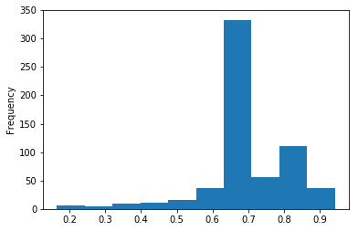

```python
pd.Series(y_pred_proba).plot.hist()
```

## 3)

```python
def get_cols(cols):
    return FunctionTransformer(lambda x: x[cols], validate=False)
```

### Different col choices

```python
cols_cat
```

```
['v6', 'v45', 'v12']
```

```python
cols_sub1 = ['v1', 'v2', 'v4']
```

```python
cols_cat + cols_sub1
```

```
['v6', 'v45', 'v12', 'v1', 'v2', 'v4']
```

```python
cols_catnum = cols_cat + cols_num
```

### Select clf

```python
clf = DecisionTreeClassifier()
```

```python
clf = RandomForestClassifier()
```

```python
clf = LogisticRegression(C=1.5)
```

```python
clf = GradientBoostingClassifier()
```

### Select X

```python
# choose cols (try out different alternatives!)
cols_num_pipeline = cols_num
cols_cat_pipeline = cols_cat + ['overdue']

X = df[cols_num_pipeline + cols_cat_pipeline]
y = df.y
```

what about cato i.e. ordinal data?

### Fit and predict

```python
numerical_pipeline = Pipeline([
    ('select', get_cols(cols_num_pipeline)),
    ('imp', Imputer()),
    ('scale', StandardScaler()
    #, ('pca', PCA(3))
     #, SelectKBest(3)
    )
])

categorical_pipeline = Pipeline([
    ('select', get_cols(cols_cat_pipeline)),
    ('imp', Imputer(strategy = 'most_frequent')),
    ('onehot', OneHotEncoder())
])

union = FeatureUnion([
    ('numeric', numerical_pipeline),
    ('categorical', categorical_pipeline)
])

pl = Pipeline([
    ('union', union),
    ('clf', clf)
])

# roc_auc_score(y_test, pl.fit(X_train, y_train).predict_proba(X_test)[:, 1])
pl.fit(X, y)
cross_val_score(pl, X, y, cv = 10, scoring='roc_auc').mean()
```

```
0.65092394523512476
```

## Feature selection

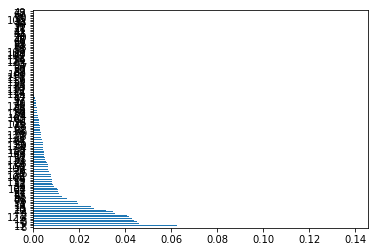

```python
# X.columns
pd.Series(pl.named_steps['clf'].feature_importances_).sort_values(ascending=False).plot.barh()
# pl.steps[1][1].get_feature_names()
```

```python
feature_imp = pd.Series(pl.named_steps['clf'].feature_importances_)
feature_imp[feature_imp.values > 0.01].index
```

```
Int64Index([  0,   1,   2,   3,   4,   5,   8,  10,  11,  13,  15,  16,  19,
             20,  21,  22,  25,  57,  78,  86,  87,  93, 104, 121],
           dtype='int64')
```

```python
pd.Series(pl.named_steps['clf'].feature_importances_).head(10)
```

```
0    0.045311
1    0.019345
2    0.040591
3    0.043869
4    0.034871
5    0.035657
6    0.007206
7    0.000000
8    0.138689
9    0.003148
dtype: float64
```

## Describe X

```python
X.shape, y.shape
```

```
((2057, 27), (2057,))
```

```python
X.describe()
```

|  | v18 | v27 | v8 | v1 | v29 | v19 | v25 | v4 | v7 | v26 | ... | v15 | v11 | v41 | v17 | v16 | v2 | v24 | v40 | v6 | v12 |
| --- | --- | --- | --- | --- | --- | --- | --- | --- | --- | --- | --- | --- | --- | --- | --- | --- | --- | --- | --- | --- | --- |
| count | 1910.000000 | 1910.000000 | 2057.000000 | 2057.000000 | 1910.000000 | 1910.000000 | 1910.000000 | 2057.000000 | 2056.000000 | 1910.000000 | ... | 1910.000000 | 2057.000000 | 1910.000000 | 1910.000000 | 1910.000000 | 2057.00000 | 1910.00000 | 1910.000000 | 2022.000000 | 2057.000000 |
| mean | 0.583770 | 1.911518 | 197.083617 | 33.634905 | 0.068063 | 0.434555 | 0.020942 | 1.000972 | 32.388132 | 0.339791 | ... | 2.193194 | 202.875061 | 0.004188 | 0.328796 | 1.206806 | 1.31016 | 0.03822 | 0.194764 | 48.885757 | 36.929023 |
| std | 0.865525 | 3.400309 | 109.459238 | 8.894507 | 0.387840 | 0.933998 | 0.157179 | 0.031174 | 11.473110 | 0.674491 | ... | 2.683371 | 80.494015 | 0.064600 | 0.665515 | 3.015875 | 0.72481 | 0.20752 | 0.458633 | 26.271963 | 28.130961 |
| min | 0.000000 | 0.000000 | 0.000000 | 7.000000 | 0.000000 | 0.000000 | 0.000000 | 1.000000 | 18.000000 | 0.000000 | ... | 0.000000 | 50.000000 | 0.000000 | 0.000000 | 0.000000 | 1.00000 | 0.00000 | 0.000000 | 1.000000 | 0.000000 |
| 25% | 0.000000 | 0.000000 | 100.000000 | 30.000000 | 0.000000 | 0.000000 | 0.000000 | 1.000000 | 24.000000 | 0.000000 | ... | 0.000000 | 190.000000 | 0.000000 | 0.000000 | 0.000000 | 1.00000 | 0.00000 | 0.000000 | 26.000000 | 15.000000 |
| 50% | 0.000000 | 1.000000 | 199.000000 | 30.000000 | 0.000000 | 0.000000 | 0.000000 | 1.000000 | 29.000000 | 0.000000 | ... | 1.000000 | 199.000000 | 0.000000 | 0.000000 | 0.000000 | 1.00000 | 0.00000 | 0.000000 | 49.000000 | 45.000000 |
| 75% | 1.000000 | 2.000000 | 199.000000 | 30.000000 | 0.000000 | 1.000000 | 0.000000 | 1.000000 | 38.000000 | 1.000000 | ... | 4.000000 | 200.000000 | 0.000000 | 0.000000 | 1.000000 | 1.00000 | 0.00000 | 0.000000 | 70.000000 | 45.000000 |
| max | 7.000000 | 32.000000 | 500.000000 | 60.000000 | 10.000000 | 7.000000 | 3.000000 | 2.000000 | 86.000000 | 5.000000 | ... | 20.000000 | 500.000000 | 1.000000 | 5.000000 | 32.000000 | 10.00000 | 2.00000 | 4.000000 | 99.000000 | 99.000000 |

8 rows × 25 columns

# Below = scratchpad

```python
variabletypes.loc[variabletypes.Test_Name.isin(X.columns)].T
```

|  | 3 | 4 | 6 | 8 | 9 | 14 | 17 | 18 | 19 | 20 | ... | 32 | 33 | 34 | 35 | 37 | 43 | 44 | 48 | 49 | 53 |
| --- | --- | --- | --- | --- | --- | --- | --- | --- | --- | --- | --- | --- | --- | --- | --- | --- | --- | --- | --- | --- | --- |
| Test_Name | v1 | v2 | v4 | v6 | v7 | v8 | v9 | v10 | v11 | v12 | ... | v24 | v25 | v26 | v27 | v29 | v35 | v36 | v40 | v41 | v45 |
| Type | Numeric | Numeric | Numeric | Categorical | Numeric | Numeric | Numeric | Numeric | Numeric | Categorical | ... | Numeric | Numeric | Numeric | Numeric | Numeric | Numeric | Numeric | Numeric | Numeric | Categorical |

2 rows × 26 columns

qq is 0 and 1 equally good as 1 and 2? if not, remove 1 from v4 as it ranges from 1 to 2.

```python
variabletypes[variabletypes.Type == 'ID']
```

|  | Test_Name | Type |
| --- | --- | --- |
| 0 | country_id | ID |
| 1 | application_id | ID |
| 2 | product_id | ID |
| 15 | customer_id | ID |